# w203_Lab3_group5_draft1: Joanna wang, Douglas(Zeliang) Xu

### Introduction

In this report, we will analyze the crime statistics for a selection of counties in North Carolina and purpose to find out some main factors of crime rate. After the initial analysis on the data, we will purpose our research question.We will then provide several policies or suggestions based on our research findings.

### Part1: Looking at the data

This part is to look at the dataset in general to grow our understand of the data:

```r
library(car)
library(sandwich)
library(lmtest)
data <- read.csv(file="crime_v2.csv", header=TRUE, sep=",",na.strings=c("`","","NA"))
objects(data)
```

```
##  [1] "avgsen"   "central"  "county"   "crmrte"   "density"  "mix"
##  [7] "pctmin80" "pctymle"  "polpc"    "prbarr"   "prbconv"  "prbpris"
## [13] "taxpc"    "urban"    "wcon"     "west"     "wfed"     "wfir"
## [19] "wloc"     "wmfg"     "wser"     "wsta"     "wtrd"     "wtuc"
## [25] "year"
```

Here we have the summary of all the veriables in the data set, to spot any anormaly.

```r
summary(data)
```

```
##      county           year        crmrte             prbarr
##  Min.   :  1.0   Min.   :87   Min.   :0.005533   Min.   :0.09277
##  1st Qu.: 52.0   1st Qu.:87   1st Qu.:0.020927   1st Qu.:0.20568
##  Median :105.0   Median :87   Median :0.029986   Median :0.27095
##  Mean   :101.6   Mean   :87   Mean   :0.033400   Mean   :0.29492
##  3rd Qu.:152.0   3rd Qu.:87   3rd Qu.:0.039642   3rd Qu.:0.34438
##  Max.   :197.0   Max.   :87   Max.   :0.098966   Max.   :1.09091
##  NA's   :6       NA's   :6    NA's   :6          NA's   :6
##     prbconv           prbpris           avgsen           polpc
##  Min.   :0.06838   Min.   :0.1500   Min.   : 5.380   Min.   :0.000746
##  1st Qu.:0.34541   1st Qu.:0.3648   1st Qu.: 7.340   1st Qu.:0.001231
##  Median :0.45283   Median :0.4234   Median : 9.100   Median :0.001485
##  Mean   :0.55128   Mean   :0.4108   Mean   : 9.647   Mean   :0.001702
##  3rd Qu.:0.58886   3rd Qu.:0.4568   3rd Qu.:11.420   3rd Qu.:0.001877
##  Max.   :2.12121   Max.   :0.6000   Max.   :20.700   Max.   :0.009054
##  NA's   :6         NA's   :6        NA's   :6        NA's   :6
##     density            taxpc             west           central
##  Min.   :0.00002   Min.   : 25.69   Min.   :0.0000   Min.   :0.0000
##  1st Qu.:0.54741   1st Qu.: 30.66   1st Qu.:0.0000   1st Qu.:0.0000
##  Median :0.96226   Median : 34.87   Median :0.0000   Median :0.0000
##  Mean   :1.42884   Mean   : 38.06   Mean   :0.2527   Mean   :0.3736
##  3rd Qu.:1.56824   3rd Qu.: 40.95   3rd Qu.:0.5000   3rd Qu.:1.0000
##  Max.   :8.82765   Max.   :119.76   Max.   :1.0000   Max.   :1.0000
##  NA's   :6         NA's   :6        NA's   :6        NA's   :6
##      urban            pctmin80           wcon            wtuc
##  Min.   :0.00000   Min.   : 1.284   Min.   :193.6   Min.   :187.6
##  1st Qu.:0.00000   1st Qu.: 9.845   1st Qu.:250.8   1st Qu.:374.6
##  Median :0.00000   Median :24.312   Median :281.4   Median :406.5
##  Mean   :0.08791   Mean   :25.495   Mean   :285.4   Mean   :411.7
##  3rd Qu.:0.00000   3rd Qu.:38.142   3rd Qu.:314.8   3rd Qu.:443.4
##  Max.   :1.00000   Max.   :64.348   Max.   :436.8   Max.   :613.2
##  NA's   :6         NA's   :6        NA's   :6       NA's   :6
##       wtrd            wfir            wser             wmfg
##  Min.   :154.2   Min.   :170.9   Min.   : 133.0   Min.   :157.4
##  1st Qu.:190.9   1st Qu.:286.5   1st Qu.: 229.7   1st Qu.:288.9
##  Median :203.0   Median :317.3   Median : 253.2   Median :320.2
##  Mean   :211.6   Mean   :322.1   Mean   : 275.6   Mean   :335.6
##  3rd Qu.:225.1   3rd Qu.:345.4   3rd Qu.: 280.5   3rd Qu.:359.6
##  Max.   :354.7   Max.   :509.5   Max.   :2177.1   Max.   :646.9
##  NA's   :6       NA's   :6       NA's   :6        NA's   :6
##       wfed            wsta            wloc            mix
##  Min.   :326.1   Min.   :258.3   Min.   :239.2   Min.   :0.01961
##  1st Qu.:400.2   1st Qu.:329.3   1st Qu.:297.3   1st Qu.:0.08074
##  Median :449.8   Median :357.7   Median :308.1   Median :0.10186
##  Mean   :442.9   Mean   :357.5   Mean   :312.7   Mean   :0.12884
##  3rd Qu.:478.0   3rd Qu.:382.6   3rd Qu.:329.2   3rd Qu.:0.15175
##  Max.   :598.0   Max.   :499.6   Max.   :388.1   Max.   :0.46512
##  NA's   :6       NA's   :6       NA's   :6       NA's   :6
##     pctymle
##  Min.   :0.06216
##  1st Qu.:0.07443
##  Median :0.07771
##  Mean   :0.08396
##  3rd Qu.:0.08350
##  Max.   :0.24871
##  NA's   :6
```

We noticed that there are 6 NAs in all the variables. To took a closer look at the last few rows of the date set to verify the NA entires.

```r
tail(data,7)
```

```
##    county year    crmrte   prbarr prbconv  prbpris avgsen      polpc
## 91    197   87 0.0141928 0.207595 1.18293 0.360825  12.23 0.00118573
## 92     NA   NA        NA       NA      NA       NA     NA         NA
## 93     NA   NA        NA       NA      NA       NA     NA         NA
## 94     NA   NA        NA       NA      NA       NA     NA         NA
## 95     NA   NA        NA       NA      NA       NA     NA         NA
## 96     NA   NA        NA       NA      NA       NA     NA         NA
## 97     NA   NA        NA       NA      NA       NA     NA         NA
##     density    taxpc west central urban pctmin80    wcon     wtuc    wtrd
## 91 0.889881 25.95258    1       0     0  5.46081 314.166 341.8803 182.802
## 92       NA       NA   NA      NA    NA       NA      NA       NA      NA
## 93       NA       NA   NA      NA    NA       NA      NA       NA      NA
## 94       NA       NA   NA      NA    NA       NA      NA       NA      NA
## 95       NA       NA   NA      NA    NA       NA      NA       NA      NA
## 96       NA       NA   NA      NA    NA       NA      NA       NA      NA
## 97       NA       NA   NA      NA    NA       NA      NA       NA      NA
##        wfir     wser   wmfg   wfed   wsta   wloc        mix    pctymle
## 91 348.1432 212.8205 322.92 391.72 385.65 306.85 0.06756757 0.07419893
## 92       NA       NA     NA     NA     NA     NA         NA         NA
## 93       NA       NA     NA     NA     NA     NA         NA         NA
## 94       NA       NA     NA     NA     NA     NA         NA         NA
## 95       NA       NA     NA     NA     NA     NA         NA         NA
## 96       NA       NA     NA     NA     NA     NA         NA         NA
## 97       NA       NA     NA     NA     NA     NA         NA         NA
```

Some of the things we see in the dataset and have lead us to some decisions: 1. 6 NAs for all columns. We will remove those entries. 2. Year is alwasy 87. We will take out the year column, because it does not help us with our crime rate analysis 3. “prbarr” max > 1. Probability should not be greater than 1. 4. “prbconv” strange characters and blank spaces; also the probability is bigger than 1 5. taxpc, what is the unit, what does it mean? Outlier at 119. Is the unit %? 6. pctmin80 data is too old 7. 15-23: different industry avg. wages 8. 24 mix: ratio of face-to-face crime 9. percentage young male (what is the age:15-24)

With the import method modified, we are able to address the missing values and the special character error in the $prbconv$ data column

### Data Cleaning

1. remove NA

```r
data <- na.omit(data)
```

2. take out year column as it does not mean anything in our analysis

```r
data_clean <- subset(data,select=-c(year))
objects(data_clean)
```

```
##  [1] "avgsen"   "central"  "county"   "crmrte"   "density"  "mix"
##  [7] "pctmin80" "pctymle"  "polpc"    "prbarr"   "prbconv"  "prbpris"
## [13] "taxpc"    "urban"    "wcon"     "west"     "wfed"     "wfir"
## [19] "wloc"     "wmfg"     "wser"     "wsta"     "wtrd"     "wtuc"
```

3. “prbarr” max > 1. Becuase this variable is supposed to represent the probability of arrest, the max should never exceed 1.

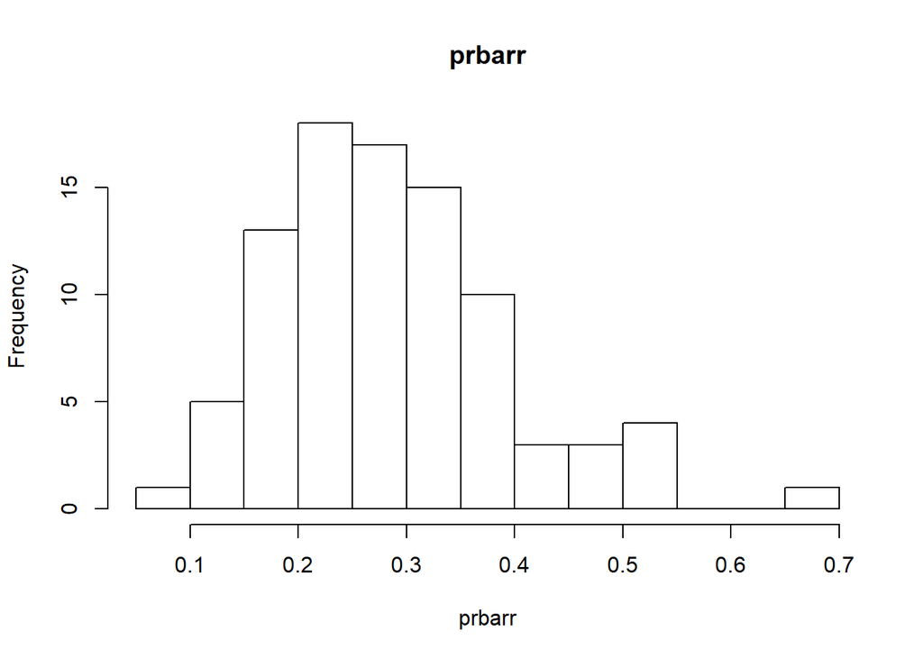

```r
data_clean <- subset(data_clean,data_clean$prbarr <1)
hist(data_clean$prbarr, breaks=20,  main="prbarr", xlab="prbarr")
```

4. “prbconv” column contains strange characters and blank spaces; Also becuase this is the probability, it should not contain entries that are bigger than 1  
   **blank space and strange characters are taken care of in data import**

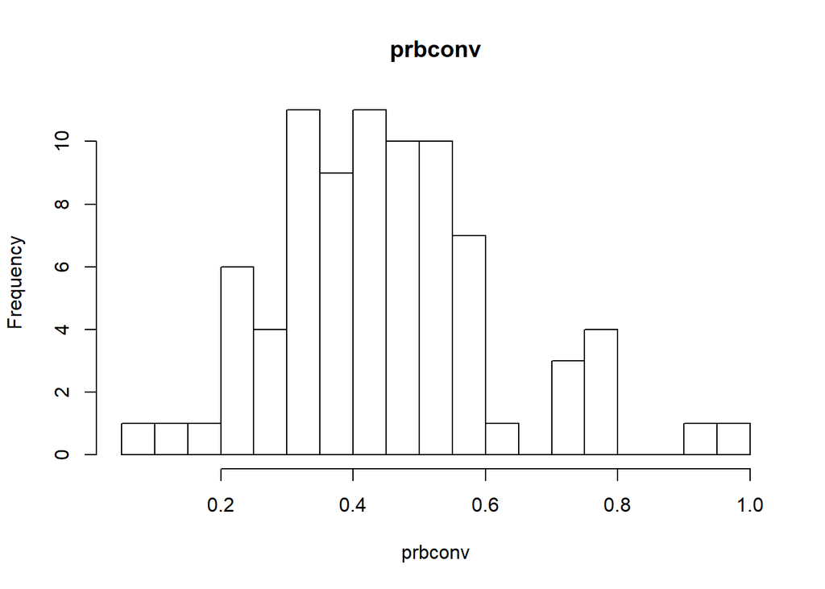

```r
data_clean <- subset(data_clean,data_clean$prbconv <1)
hist(data_clean$prbconv, breaks=20, main="prbconv", xlab="prbconv")
```

5. taxpc: There seems to be some anomaly that is very far apart from other data points, but we have no evidence to say whether the data has anomaly or not. It could be an error or it could just be that the county has high tax per capita

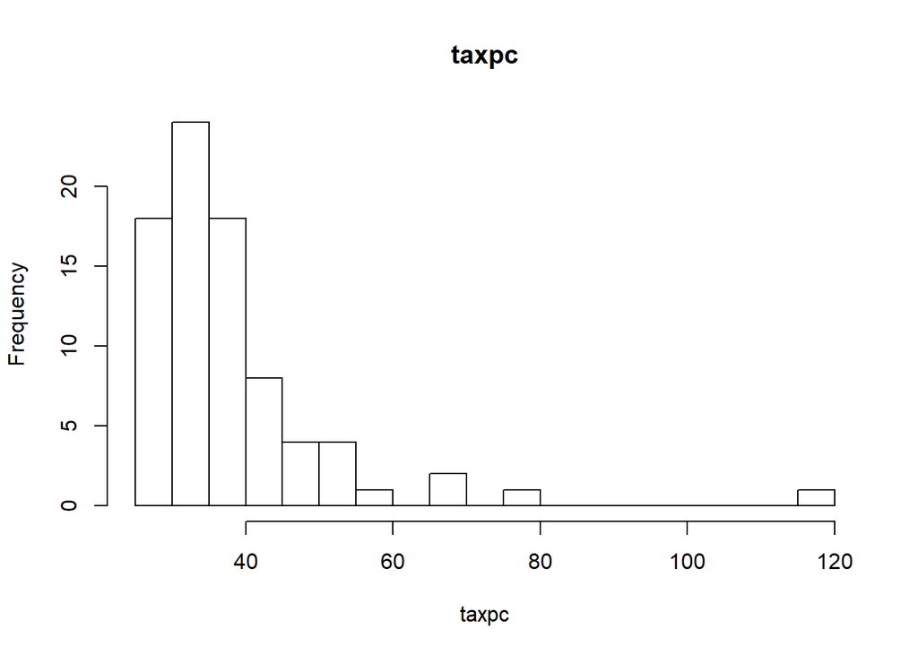

```r
hist(data_clean$taxpc, breaks=20, main="taxpc", xlab="taxpc")
```

6. over-paid service industry: we found that the maximum value of the avg. weekly wage of service industry is above 2000, which is way more than the other industries. Based on the background knowledge, we don’t believe there should be significant difference between the service industry and other industries in terms of compensation difference, and the data point above 2000 should be an error in the data, and we decided to remove them

```r
data_clean <- subset(data_clean, data_clean$wser<1000)
summary(data_clean$wser)
```

```
##    Min. 1st Qu.  Median    Mean 3rd Qu.    Max.
##   133.0   230.3   253.6   255.2   278.1   391.3
```

### EDA

1. As the first part of the data analysis, we are taking a look at the distributions of the dependent variable:

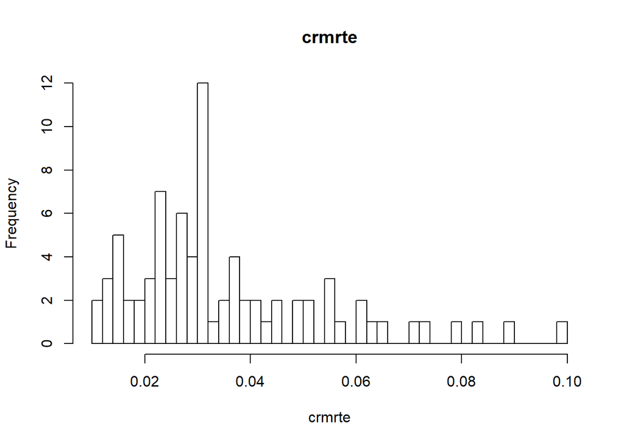

```r
hist(data_clean$crmrte,breaks=50, main="crmrte", xlab="crmrte")
```

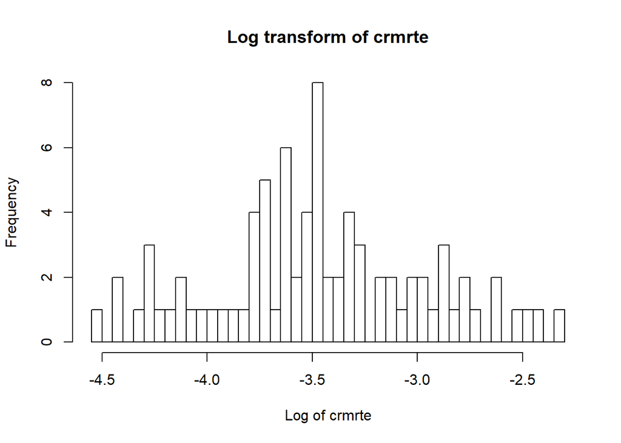

```r
hist(log(data_clean$crmrte),breaks=50, main="Log transform of crmrte", xlab="Log of crmrte")
```

2. As the second part of the EDA, we take an initial look at the simple correlation between each variable inside the dataframe to help us understand the general correlations betwen each varible and the dependent variable to help identify the explanatory variables of interest

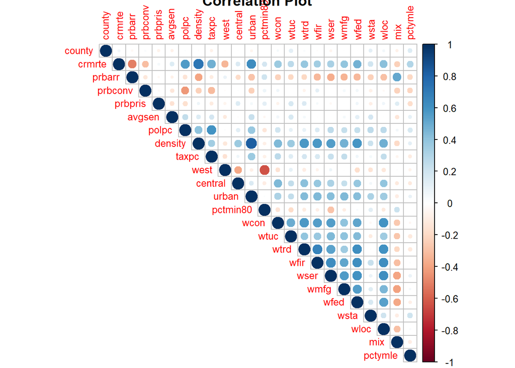

```r
# correlation plot
library(corrplot)
corrplot(cor(data_clean[,sapply(data_clean,is.numeric)]),is.corr=T, method = "circle", type='upper',main = "Correlation Plot", tl.cex=0.8)
```

### Research Question

After the initial data cleaning and data analysis, we have defined our research question to be: how to reduce crime rate within North Carolina, and especially what are the most effective measures in reducing crime rate.

The question is asked to help the political campaign to propose effective strategies to reduce crime rate, especially in the area that might have been neglected before. From the simple correlation plot, we found that variable $mix$ has strong positive correlation with $prbarr$. It can make sense because face-to-face crimes are more severe and usually have more police concentration and resources that lead to higher probability of arrest. However, it might not be very easy for non face-to-face crime, which is still the majority of crimes that happened, but actually seem to have pretty low arrest rate. This conclusion can be obtained by the fact that crime rate ($crmrte$) is negatively correlated with probability of arrest($prbarr$) while percentage of face-to-face crime ($mix$) is positively correlated with probability of arrest ($prbarr$). Therefore, how to increase $prbarr$ for non face-to-face crime is really the strategy we need to focus our energy on.

### Fitting model 1

Based on the understanding of what each parameter stands for, we have chosen crmrte as the only dependent variable to use for our analysis. The variable is a direct indicator of average crime commited to North Carolina counties. To start with, we took a look at the distribution of the dataset.

From the analysis of the EDA, the distribution of crmrte does not look particularly normal, but the log transformed crmrte looks much more normally distributed. To reduce the standard error in the model building process, we decided that in our model fitting, we are going to use the log transformed $crmrte$ as our dependent variable.  
That being said, we are creating another variable that indicates the log transformed $crmrte$

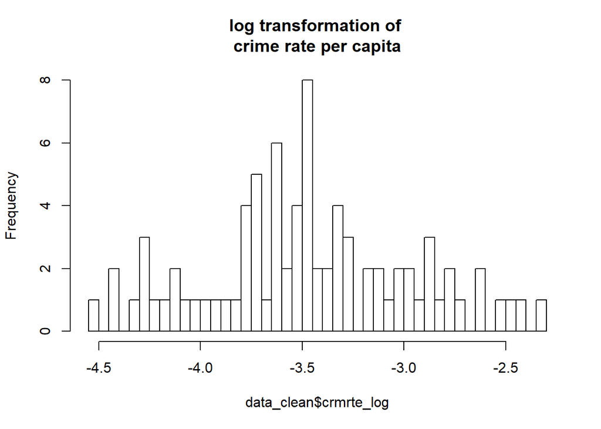

```r
data_clean$crmrte_log <- log(data_clean$crmrte)
hist(data_clean$crmrte_log, breaks=50, main="log transformation of
crime rate per capita")
```

Looking at the other variables, and the simple correlation plot in initial EDA, we are proposing the explanatory variables that we believe contribute to crime rate:

1. prbarr: the probability of arrest should be a direct contributing factor to crime rate. In other words, if people who have potential to commit a crime believe the chance of them getting arrested is small, then it might encourage them to commit a crime
2. prbconv: after getting arrested, getting suspects convicted are the only way to let them take the punishment they deserve.
3. prbpris
4. avgsen: both probability of prison sentence reflect the severity of the punishment, which should directly impact the crime rate

With the above being proposed, we decided to take a look at the distribution of each explanatory variable:

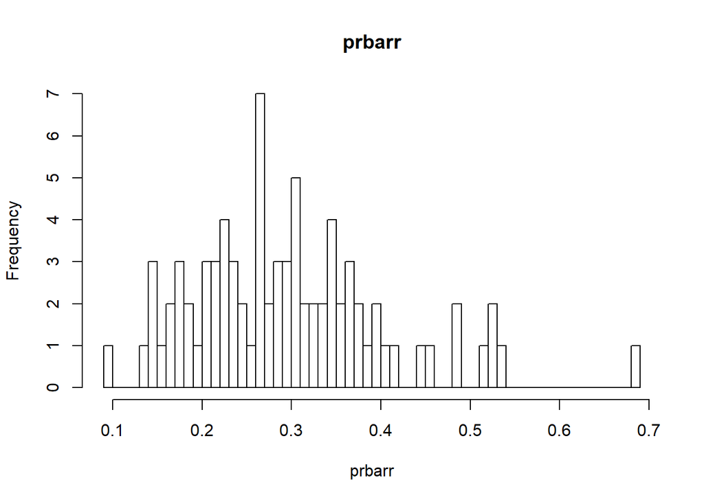

```r
# prbarr
hist(data_clean$prbarr,breaks=50,main="prbarr", xlab="prbarr")
```

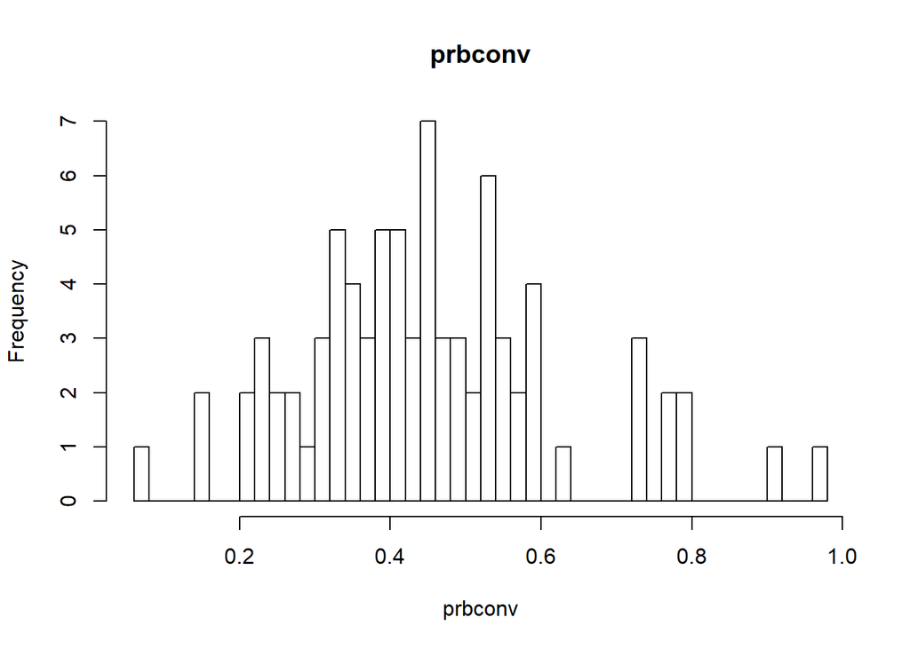

```r
#prbconv
hist(data_clean$prbconv,breaks=50,main="prbconv", xlab="prbconv")
```

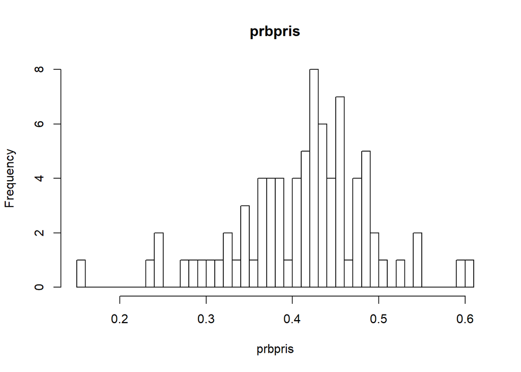

```r
#prbpris
hist(data_clean$prbpris,breaks=50,main="prbpris", xlab="prbpris")
```

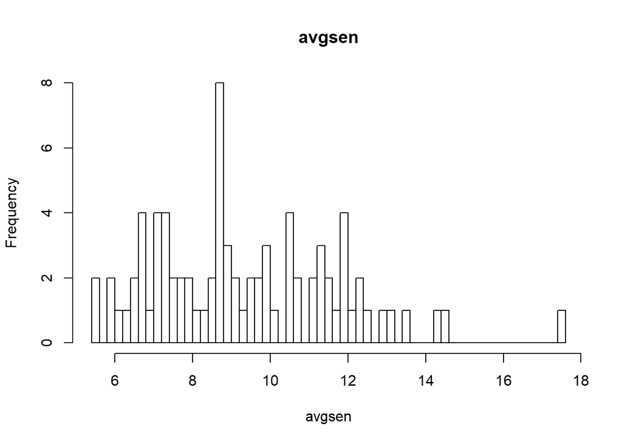

```r
#avgsen
hist(data_clean$avgsen,breaks=50,main="avgsen", xlab="avgsen")
```

The above histograms of each explanatory variable all seem rather normally distributed, with some anomalies implied in $prbarr$ and $avgsen$. However, we don’t think there is enough evidence to make a decision on whether the data is anomaly or not, and we will use the data for model building.

Next, we want to look at the scatterplot between each key explanatory variable and the dependent variable to decide on model specification:

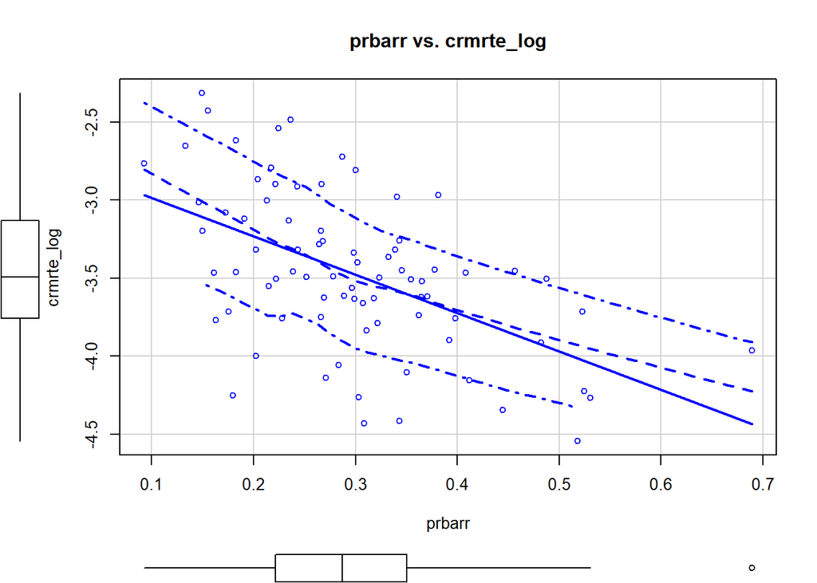

```r
scatterplot(data_clean$prbarr,data_clean$crmrte_log, main="prbarr vs. crmrte_log", xlab="prbarr", ylab="crmrte_log")
```

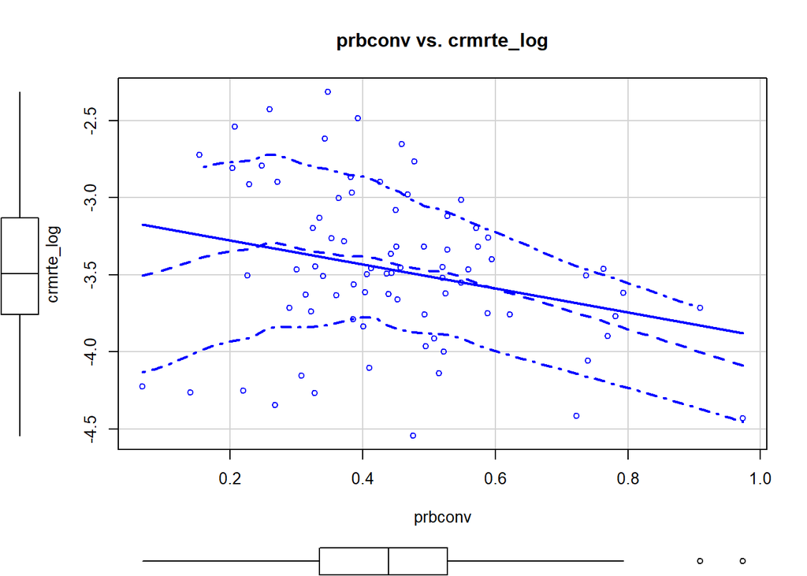

```r
scatterplot(data_clean$prbconv,data_clean$crmrte_log, main="prbconv vs. crmrte_log", xlab="prbconv", ylab="crmrte_log")
```

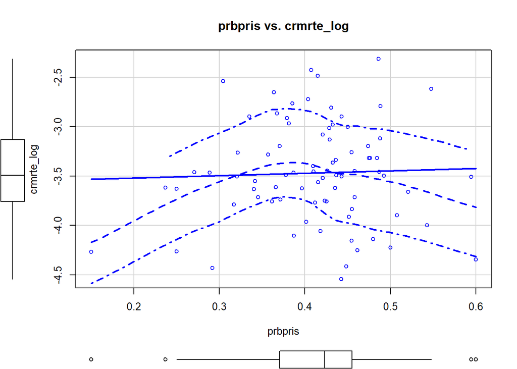

```r
scatterplot(data_clean$prbpris,data_clean$crmrte_log, main="prbpris vs. crmrte_log", xlab="prbpris", ylab="crmrte_log")
```